Recently I looked at how discs have changed through time - and how manufacturers have updated their disc technology. It was suggested that I should look at how companies compare in the consistency of their discs.

Looking at disc consistency itself is a bit difficult to do - I don’t have, for example, access to have individual reviews of thousands of individual [Innova Destroyers](https://amzn.to/3ezunur). Instead what we can do is compare manufacturer flight numbers to the number reported by Infinite Discs. On their website, users can give their own flight numbers to a disc and then Infinite posts those aggregated flight numbers to each manufacturer’s page (e.g. See all of Discraft’s discs and see how the flight numbers are not a 1:1 match to Discraft’s own numbers).

Of course, there’s still differences like different plastics, runs, and other sources of variation - but by comparing Infinite’s numbers to manufacturer numbers we can at least ask questions like:

- Which companies have the most predictable flight numbers?
- Which individual discs are most true to their numbers? Which are most divergent?

So, let’s get into it.

# Which companies have the most predictable flight numbers?

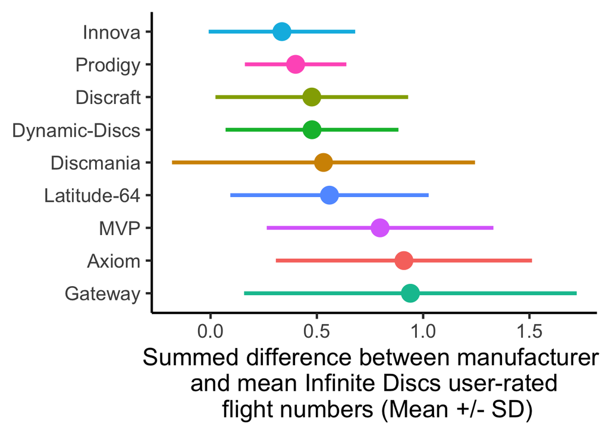

In the above plot, [Innova](https://amzn.to/3wQK3zF) comes in as having the *most* accurate flight numbers and Gateway has the *least*. It’s interesting to note that [Gateway](https://amzn.to/2UVT7pM) and [Discmania](https://amzn.to/36IOylg) both have really large error bars - this means that some of their discs are exactly what people expect and some are nothing like what people expected.

Shown above is the “total difference” with no sense of directionality (i.e. we don’t know if people thought these discs were “too fast” for their numbers or “too slow”…we just know if they were as expected or not). For every disc I calculated the difference between each manufacturer flight number and Infinite Disc’s flight numbers and then added up the absolute value of all those differences. Then, the mean value is presented for each manufacturer. For example, an [Axiom Envy](https://amzn.to/3BiZ0Or) has a manufacturer’s speed of 3 but Infinite users scored it as 2.7. We repeat that calculation for each flight number and add up all the differences to get a total divergence score.

tl;dr: Discs with high numbers are bad. Discs with low (or zero) are good - exactly as expected by the thrower.

Next, let’s consider some flight numbers with directionality preserved. To save you from chart overload, we will only look at Speed. The other values all sort of correlated as expected from that anyway (i.e. if users thought a disc was faster than its numbers, they also thought it had less turn and more fade).

# How do companies compare across their expected speed?

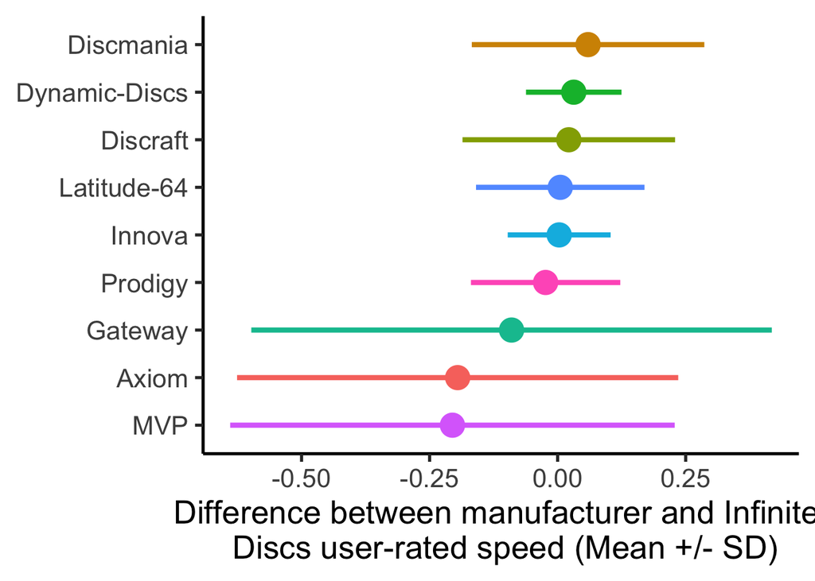

Lastly, here’s a couple tables of discs that are most true (divergence = 0) and some that are least true (divergence score > 2) from their manufacturer flight numbers.

# What discs are most true to their numbers?

|  | Speed | Glide | Turn | Fade |
| --- | --- | --- | --- | --- |
| [Discmania Dd3](https://www.amazon.com/s/ref=as_li_ss_tl?k=Discmania+dd3&i=sporting&ref=nb_sb_noss_2&linkCode=ll2&tag=johnmmola-20&linkId=36898e3536564417d118fbf011320809&language=en_US) | 12 | 5 | -1.0 | 3.0 |
| [Discmania Md1](https://www.amazon.com/s/ref=as_li_ss_tl?k=Discmania+md1&i=sporting&ref=nb_sb_noss_2&linkCode=ll2&tag=johnmmola-20&linkId=36898e3536564417d118fbf011320809&language=en_US) | 4 | 4 | 0.0 | 2.0 |
| [Discmania Link](https://www.amazon.com/s/ref=as_li_ss_tl?k=Discmania+link&i=sporting&ref=nb_sb_noss_2&linkCode=ll2&tag=johnmmola-20&linkId=36898e3536564417d118fbf011320809&language=en_US) | 2 | 3 | 0.0 | 1.0 |
| [Discraft Wildcat](https://www.amazon.com/s/ref=as_li_ss_tl?k=Discraft+wildcat&i=sporting&ref=nb_sb_noss_2&linkCode=ll2&tag=johnmmola-20&linkId=36898e3536564417d118fbf011320809&language=en_US) | 11 | 5 | -2.0 | 3.0 |
| [Discraft Talon](https://www.amazon.com/s/ref=as_li_ss_tl?k=Discraft+talon&i=sporting&ref=nb_sb_noss_2&linkCode=ll2&tag=johnmmola-20&linkId=36898e3536564417d118fbf011320809&language=en_US) | 8 | 3 | 1.0 | 3.0 |
| [Dynamic Discs Witness](https://www.amazon.com/s/ref=as_li_ss_tl?k=Dynamic+Discs+witness&i=sporting&ref=nb_sb_noss_2&linkCode=ll2&tag=johnmmola-20&linkId=36898e3536564417d118fbf011320809&language=en_U… | 8 | 6 | -3.0 | 1.0 |
| [Dynamic Discs Guard](https://www.amazon.com/s/ref=as_li_ss_tl?k=Dynamic+Discs+guard&i=sporting&ref=nb_sb_noss_2&linkCode=ll2&tag=johnmmola-20&linkId=36898e3536564417d118fbf011320809&language=en_US) | 2 | 5 | 0.0 | 0.5 |
| [Gateway Rage](https://www.amazon.com/s/ref=as_li_ss_tl?k=Gateway+rage&i=sporting&ref=nb_sb_noss_2&linkCode=ll2&tag=johnmmola-20&linkId=36898e3536564417d118fbf011320809&language=en_US) | 10 | 5 | -0.5 | 3.5 |
| [Gateway Hybrid](https://www.amazon.com/s/ref=as_li_ss_tl?k=Gateway+hybrid&i=sporting&ref=nb_sb_noss_2&linkCode=ll2&tag=johnmmola-20&linkId=36898e3536564417d118fbf011320809&language=en_US) | 7 | 4 | -0.5 | 3.0 |
| [Innova Destroyer](https://www.amazon.com/s/ref=as_li_ss_tl?k=Innova+destroyer&i=sporting&ref=nb_sb_noss_2&linkCode=ll2&tag=johnmmola-20&linkId=36898e3536564417d118fbf011320809&language=en_US) | 12 | 5 | -1.0 | 3.0 |
| [Innova Krait](https://www.amazon.com/s/ref=as_li_ss_tl?k=Innova+krait&i=sporting&ref=nb_sb_noss_2&linkCode=ll2&tag=johnmmola-20&linkId=36898e3536564417d118fbf011320809&language=en_US) | 11 | 5 | -1.0 | 2.0 |
| [Innova Max](https://www.amazon.com/s/ref=as_li_ss_tl?k=Innova+max&i=sporting&ref=nb_sb_noss_2&linkCode=ll2&tag=johnmmola-20&linkId=36898e3536564417d118fbf011320809&language=en_US) | 11 | 3 | 0.0 | 5.0 |
| [Innova Cheetah](https://www.amazon.com/s/ref=as_li_ss_tl?k=Innova+cheetah&i=sporting&ref=nb_sb_noss_2&linkCode=ll2&tag=johnmmola-20&linkId=36898e3536564417d118fbf011320809&language=en_US) | 6 | 4 | -2.0 | 2.0 |
| [Innova Gargoyle](https://www.amazon.com/s/ref=as_li_ss_tl?k=Innova+gargoyle&i=sporting&ref=nb_sb_noss_2&linkCode=ll2&tag=johnmmola-20&linkId=36898e3536564417d118fbf011320809&language=en_US) | 6 | 3 | -1.0 | 2.0 |
| [Innova Python](https://www.amazon.com/s/ref=as_li_ss_tl?k=Innova+python&i=sporting&ref=nb_sb_noss_2&linkCode=ll2&tag=johnmmola-20&linkId=36898e3536564417d118fbf011320809&language=en_US) | 7 | 3 | -1.0 | 2.0 |
| [Innova Raven](https://www.amazon.com/s/ref=as_li_ss_tl?k=Innova+raven&i=sporting&ref=nb_sb_noss_2&linkCode=ll2&tag=johnmmola-20&linkId=36898e3536564417d118fbf011320809&language=en_US) | 6 | 4 | -2.0 | 2.0 |
| [Innova Teebird](https://www.amazon.com/s/ref=as_li_ss_tl?k=Innova+teebird&i=sporting&ref=nb_sb_noss_2&linkCode=ll2&tag=johnmmola-20&linkId=36898e3536564417d118fbf011320809&language=en_US) | 7 | 5 | 0.0 | 2.0 |
| [Innova Viking](https://www.amazon.com/s/ref=as_li_ss_tl?k=Innova+viking&i=sporting&ref=nb_sb_noss_2&linkCode=ll2&tag=johnmmola-20&linkId=36898e3536564417d118fbf011320809&language=en_US) | 9 | 4 | -1.0 | 2.0 |
| [Innova Barracuda](https://www.amazon.com/s/ref=as_li_ss_tl?k=Innova+barracuda&i=sporting&ref=nb_sb_noss_2&linkCode=ll2&tag=johnmmola-20&linkId=36898e3536564417d118fbf011320809&language=en_US) | 5 | 4 | -2.0 | 3.0 |
| [Innova Bulldog](https://www.amazon.com/s/ref=as_li_ss_tl?k=Innova+bulldog&i=sporting&ref=nb_sb_noss_2&linkCode=ll2&tag=johnmmola-20&linkId=36898e3536564417d118fbf011320809&language=en_US) | 4 | 3 | 0.0 | 2.0 |
| [Innova Griffin](https://www.amazon.com/s/ref=as_li_ss_tl?k=Innova+griffin&i=sporting&ref=nb_sb_noss_2&linkCode=ll2&tag=johnmmola-20&linkId=36898e3536564417d118fbf011320809&language=en_US) | 5 | 3 | 1.0 | 3.0 |
| [Innova Lycan](https://www.amazon.com/s/ref=as_li_ss_tl?k=Innova+lycan&i=sporting&ref=nb_sb_noss_2&linkCode=ll2&tag=johnmmola-20&linkId=36898e3536564417d118fbf011320809&language=en_US) | 4 | 5 | 0.0 | 1.0 |
| [Innova Scorpion](https://www.amazon.com/s/ref=as_li_ss_tl?k=Innova+scorpion&i=sporting&ref=nb_sb_noss_2&linkCode=ll2&tag=johnmmola-20&linkId=36898e3536564417d118fbf011320809&language=en_US) | 5 | 5 | -1.0 | 2.0 |
| [Innova Aviar](https://www.amazon.com/s/ref=as_li_ss_tl?k=Innova+aviar&i=sporting&ref=nb_sb_noss_2&linkCode=ll2&tag=johnmmola-20&linkId=36898e3536564417d118fbf011320809&language=en_US) | 2 | 3 | 0.0 | 1.0 |
| [Innova Birdie](https://www.amazon.com/s/ref=as_li_ss_tl?k=Innova+birdie&i=sporting&ref=nb_sb_noss_2&linkCode=ll2&tag=johnmmola-20&linkId=36898e3536564417d118fbf011320809&language=en_US) | 1 | 2 | 0.0 | 0.0 |
| [Innova Classic Roc](https://www.amazon.com/s/ref=as_li_ss_tl?k=Innova+classic+roc&i=sporting&ref=nb_sb_noss_2&linkCode=ll2&tag=johnmmola-20&linkId=36898e3536564417d118fbf011320809&language=en_US) | 3 | 3 | 0.0 | 2.0 |
| [Innova Coupe](https://www.amazon.com/s/ref=as_li_ss_tl?k=Innova+coupe&i=sporting&ref=nb_sb_noss_2&linkCode=ll2&tag=johnmmola-20&linkId=36898e3536564417d118fbf011320809&language=en_US) | 2 | 3 | -1.0 | 1.0 |
| [Innova Nova](https://www.amazon.com/s/ref=as_li_ss_tl?k=Innova+nova&i=sporting&ref=nb_sb_noss_2&linkCode=ll2&tag=johnmmola-20&linkId=36898e3536564417d118fbf011320809&language=en_US) | 2 | 3 | 0.0 | 0.0 |
| [Innova Pig](https://www.amazon.com/s/ref=as_li_ss_tl?k=Innova+pig&i=sporting&ref=nb_sb_noss_2&linkCode=ll2&tag=johnmmola-20&linkId=36898e3536564417d118fbf011320809&language=en_US) | 3 | 1 | 0.0 | 3.0 |
| [Innova Stud](https://www.amazon.com/s/ref=as_li_ss_tl?k=Innova+stud&i=sporting&ref=nb_sb_noss_2&linkCode=ll2&tag=johnmmola-20&linkId=36898e3536564417d118fbf011320809&language=en_US) | 3 | 3 | 0.0 | 2.0 |
| [Latitude 64 Primitus](https://www.amazon.com/s/ref=as_li_ss_tl?k=Latitude+64+primitus&i=sporting&ref=nb_sb_noss_2&linkCode=ll2&tag=johnmmola-20&linkId=36898e3536564417d118fbf011320809&language=en_US) | 9 | 5 | 0.0 | 2.0 |
| [Latitude 64 Medius](https://www.amazon.com/s/ref=as_li_ss_tl?k=Latitude+64+medius&i=sporting&ref=nb_sb_noss_2&linkCode=ll2&tag=johnmmola-20&linkId=36898e3536564417d118fbf011320809&language=en_US) | 5 | 5 | -1.0 | 2.0 |
| [Latitude 64 Macana](https://www.amazon.com/s/ref=as_li_ss_tl?k=Latitude+64+macana&i=sporting&ref=nb_sb_noss_2&linkCode=ll2&tag=johnmmola-20&linkId=36898e3536564417d118fbf011320809&language=en_US) | 2 | 5 | 0.0 | 1.0 |
| [Prodigy F3](https://www.amazon.com/s/ref=as_li_ss_tl?k=Prodigy+f3&i=sporting&ref=nb_sb_noss_2&linkCode=ll2&tag=johnmmola-20&linkId=36898e3536564417d118fbf011320809&language=en_US) | 7 | 5 | -1.0 | 2.0 |
| [Prodigy Pa1](https://www.amazon.com/s/ref=as_li_ss_tl?k=Prodigy+pa1&i=sporting&ref=nb_sb_noss_2&linkCode=ll2&tag=johnmmola-20&linkId=36898e3536564417d118fbf011320809&language=en_US) | 3 | 3 | 0.0 | 2.0 |

# What individual discs are the most unlike their numbers?

|  | Speed | Glide | Turn | Fade |
| --- | --- | --- | --- | --- |
| [Discmania Enigma](https://www.amazon.com/s/ref=as_li_ss_tl?k=Discmania+enigma&i=sporting&ref=nb_sb_noss_2&linkCode=ll2&tag=johnmmola-20&linkId=36898e3536564417d118fbf011320809&language=en_US) | 13 | 5 | -1.0 | 3 |
| [Discmania Md5](https://www.amazon.com/s/ref=as_li_ss_tl?k=Discmania+md5&i=sporting&ref=nb_sb_noss_2&linkCode=ll2&tag=johnmmola-20&linkId=36898e3536564417d118fbf011320809&language=en_US) | 5 | 4 | 0.0 | 2 |
| [Discmania P3](https://www.amazon.com/s/ref=as_li_ss_tl?k=Discmania+p3&i=sporting&ref=nb_sb_noss_2&linkCode=ll2&tag=johnmmola-20&linkId=36898e3536564417d118fbf011320809&language=en_US) | 3 | 2 | 0.0 | 3 |
| [Discraft Flick](https://www.amazon.com/s/ref=as_li_ss_tl?k=Discraft+flick&i=sporting&ref=nb_sb_noss_2&linkCode=ll2&tag=johnmmola-20&linkId=36898e3536564417d118fbf011320809&language=en_US) | 9 | 4 | 1.0 | 4 |
| [Dynamic Discs Escape](https://www.amazon.com/s/ref=as_li_ss_tl?k=Dynamic+Discs+escape&i=sporting&ref=nb_sb_noss_2&linkCode=ll2&tag=johnmmola-20&linkId=36898e3536564417d118fbf011320809&language=en_US) | 9 | 5 | 1.0 | 2 |
| [Gateway Apache](https://www.amazon.com/s/ref=as_li_ss_tl?k=Gateway+apache&i=sporting&ref=nb_sb_noss_2&linkCode=ll2&tag=johnmmola-20&linkId=36898e3536564417d118fbf011320809&language=en_US) | 9 | 6 | -1.0 | 2 |
| [Gateway Diablo](https://www.amazon.com/s/ref=as_li_ss_tl?k=Gateway+diablo&i=sporting&ref=nb_sb_noss_2&linkCode=ll2&tag=johnmmola-20&linkId=36898e3536564417d118fbf011320809&language=en_US) | 9 | 5 | 0.0 | 2 |
| [Gateway Illusion](https://www.amazon.com/s/ref=as_li_ss_tl?k=Gateway+illusion&i=sporting&ref=nb_sb_noss_2&linkCode=ll2&tag=johnmmola-20&linkId=36898e3536564417d118fbf011320809&language=en_US) | 12 | 5 | -1.0 | 2 |
| [Gateway Speed Demon](https://www.amazon.com/s/ref=as_li_ss_tl?k=Gateway+speed+demon&i=sporting&ref=nb_sb_noss_2&linkCode=ll2&tag=johnmmola-20&linkId=36898e3536564417d118fbf011320809&language=en_US) | 12 | 4 | 0.0 | 3 |
| [Gateway Blaze](https://www.amazon.com/s/ref=as_li_ss_tl?k=Gateway+blaze&i=sporting&ref=nb_sb_noss_2&linkCode=ll2&tag=johnmmola-20&linkId=36898e3536564417d118fbf011320809&language=en_US) | 6 | 4 | 0.0 | 3 |
| [Gateway Voodoo](https://www.amazon.com/s/ref=as_li_ss_tl?k=Gateway+voodoo&i=sporting&ref=nb_sb_noss_2&linkCode=ll2&tag=johnmmola-20&linkId=36898e3536564417d118fbf011320809&language=en_US) | 2 | 3 | 0.0 | 2 |
| [Latitude 64 Saint Pro](https://www.amazon.com/s/ref=as_li_ss_tl?k=Latitude+64+saint+pro&i=sporting&ref=nb_sb_noss_2&linkCode=ll2&tag=johnmmola-20&linkId=36898e3536564417d118fbf011320809&language=en_U… | 8 | 5 | -0.5 | 2 |
| [Latitude 64 Trident](https://www.amazon.com/s/ref=as_li_ss_tl?k=Latitude+64+trident&i=sporting&ref=nb_sb_noss_2&linkCode=ll2&tag=johnmmola-20&linkId=36898e3536564417d118fbf011320809&language=en_US) | 6 | 4 | -0.5 | 3 |
| [MVP Tesla](https://www.amazon.com/s/ref=as_li_ss_tl?k=MVP+tesla&i=sporting&ref=nb_sb_noss_2&linkCode=ll2&tag=johnmmola-20&linkId=36898e3536564417d118fbf011320809&language=en_US) | 9 | 5 | -1.0 | 2 |
| [MVP Entropy](https://www.amazon.com/s/ref=as_li_ss_tl?k=MVP+entropy&i=sporting&ref=nb_sb_noss_2&linkCode=ll2&tag=johnmmola-20&linkId=36898e3536564417d118fbf011320809&language=en_US) | 3 | 3 | 0.0 | 4 |

There ya have it. Does this match what you expect? Are the numbers simply just made up? I think this analysis really just scratches the surface and shows what could be possible with better data. We could compare plastics, runs, retooling of molds, different user ratings, etc. I’d reckon a big part of why Innova scores so well is because it’s sort of the “Standard”. All 12, 5, -1, 3 drivers are judged against the [Innova Destroyers](https://amzn.to/3ezunur) as the standard. So anything that diverges from your expectation as a “Destroyer Replacement” gets funky numbers (even though Destroyers are known for their big differences between runs…).

Anyway - I hope y’all found this enjoyable. :)

If you like these analyses please consider supporting my project by purchasing discs through the Amazon or Infinite Discs links provided above. Head over to my disc database to explore all of Infinite Disc’s stock in a simple table.